# Supervised ML

```r
# Note that it can be worth externally diminishing the contrast of this plot in
# order to better visualize the differences of colors
```

Until now, we have explored the mean absolute SHAP values at different levels (per class, per model, per classification). These represented the magnitude of the feature effects, i.e., the importance (or influence). But the direction of the effect is also worth exploring. The direction is given by the (mean) raw SHAP values. So now we will directly compute the overall mean raw SHAP values for each classification, by applying the same steps of averaging and normalization previously employed for exploring the magnitude. In that case the sum used in the normalization is not the sum of the mean raw SHAP values but the sum of the mean absolute SHAP values!

```r
## List containing, for each classification, the overall mean raw SHAP values
overallshap_dir <- lapply(c("IHC", "Ternary", "Binary"), function(classif) {
    # Creating an internal list with the models corresponding to one
    # classification only
    listmodels <- fullplotshap[grep(classif, names(fullplotshap))]
    # Calculating the averages across all classes
    listclassavg <- lapply(listmodels, function(model) {
        list(absavgclass = rowMeans(model$magn_shap_values), avgclassshap = rowMeans(model$dir_shap_values))
    })
    # Applying sum normalization for each model type
    listmodelavg <- lapply(listclassavg, function(mod) {
        mod$avgclassshap/sum(mod$absavgclass)
    })
    # Averaging the normalized SHAP values across all model types
    rowMeans(as.data.frame(listmodelavg))
})
names(overallshap_dir) <- c("IHC", "Ternary", "Binary")
# Converting the list to table
(overallshap_dir <- as.data.frame(overallshap_dir))
```

```
                              IHC       Ternary        Binary
B_cells             -7.948747e-06  8.125053e-07  4.648978e-16
Cytotoxic_cells     -2.170946e-05 -7.628478e-07 -4.979460e-16
Dendritic_cells     -5.852969e-06  4.775874e-07 -2.561110e-17
Eosinophils         -9.906978e-06  4.907211e-08  8.863637e-18
Macrophages         -1.095698e-05  5.045540e-06 -1.200408e-15
Mast_cells          -7.090910e-06  1.312335e-06  6.668835e-19
NK_cells            -7.170870e-06  1.578742e-06 -4.367944e-16
Neutrophils         -1.971003e-05 -1.207227e-06 -4.650324e-18
T_cells_CD4          3.535396e-06 -7.646111e-07 -1.567147e-17
T_cells_CD8         -5.112840e-06  3.919699e-06  3.034615e-16
T_cells_gamma_delta -1.390634e-05 -5.354586e-07 -4.982743e-18
T_regulatory_cells  -1.315563e-07  8.112775e-06  7.538687e-16
Macrophages_M1      -1.234121e-05 -3.685276e-08  1.847840e-16
Macrophages_M2      -9.264516e-06  8.286806e-07 -1.389889e-15
Endothelial          6.825324e-06  2.364710e-08  2.068757e-17
Fibroblasts         -9.610744e-06  3.240032e-06  2.516766e-18
Monocytes           -3.196481e-05  1.661648e-06 -4.804560e-16
Plasma_cells        -2.673211e-05 -8.392768e-08  3.547082e-16
Immune_Score        -5.391421e-06  6.813507e-08  8.792744e-17
counts               1.944416e-04 -2.373945e-05 -1.177058e-15
```

Since having applied successive steps of averaging and normalization to the mean raw SHAP values ultimately distorts the true information on the magnitude (it is the mean absolute SHAP value that truly represents the importance/influence) we need to mix the two types of values (overall mean raw and absolute SHAP values). We can therefore compute a compound plot showing the direction of the effect of the 10 most important features (for each classification) and using a color gradient to express the (true) magnitude of the effect.

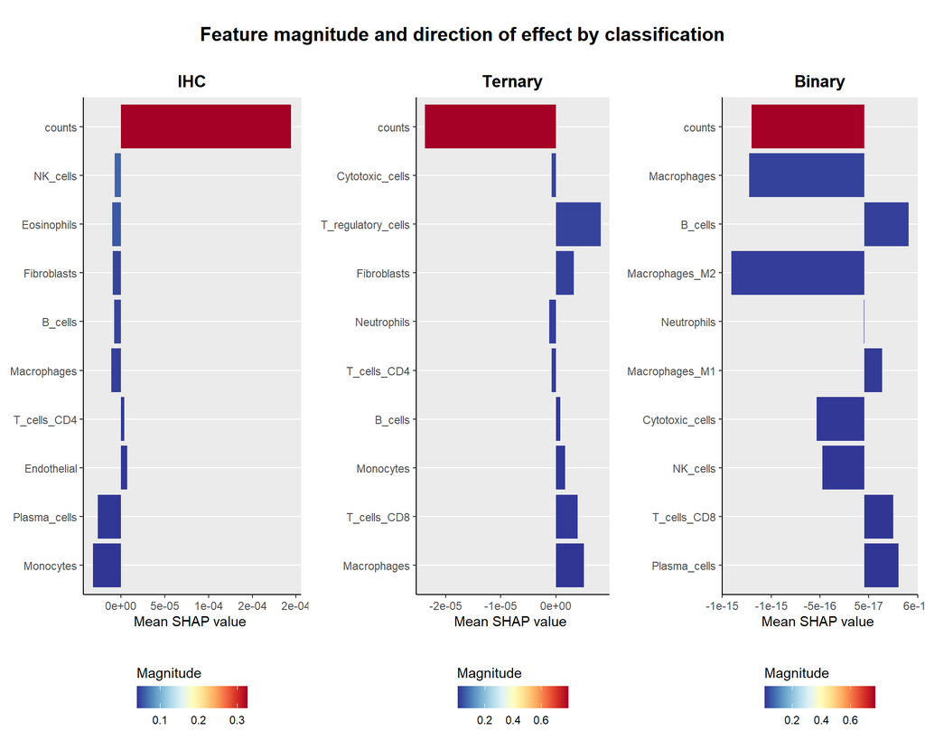

```r
## Plots of the 10 most important features for ach classification
overallshapplot_dir <- lapply(colnames(overallshap_dir), function(classif){ # List of plots

  ordinfl <- order(overallshap[,classif], decreasing = T) # Ordered vector containing the names of the features from most to least important
  df <- data.frame(immunvar=rownames(overallshap_dir), shap=overallshap_dir[,classif], row.names = NULL)
  df <- df[ordinfl[1:10],] # Selecting the raw SHAP values (direction of the effect) corresponding to the 10 most important features
  df$immunvar <- factor(df$immunvar, levels = rev(rownames(overallshap)[ordinfl[1:10]]))

  colpal <- rev(colorRampPalette(RColorBrewer::brewer.pal(11,"RdYlBu"))(50)) # Gradient of colors

  ggplot(df, aes(x = shap, y = immunvar)) +
    geom_col(aes(fill = overallshap[ordinfl,classif][1:10])) + # Using the absolute SHAP values (magnitude) of the 10 most important features to fill the bars with colors
    scale_fill_gradientn(colours = colpal) + # Mapping the color gradient to these 10 specific values in order to have nice gradient colors
    labs(x = "Mean SHAP value \n", y = NULL, title = classif, fill = "Magnitude") +
    scale_x_continuous(labels = function(x) sprintf("%.e", x)) +
    theme_gray() +
    theme(panel.grid.major.x = element_blank(), panel.grid.minor = element_blank(), axis.line = element_line(color = "black"), plot.title = element_text(face = "bold", hjust = 0.5), legend.position = "bottom", legend.title.position = "top")
    })
names(overallshapplot_dir) <- colnames(overallshap_dir)

# Grid with all the plots
grid <- plot_grid(plotlist=overallshapplot_dir, ncol = 3)
# Common title
title <- ggdraw() + draw_label("Feature magnitude and direction of effect by classification", fontface='bold', size=15)
# Final figure
plot_grid(title, grid, ncol=1, nrow = 2, rel_heights=c(0.1, 1))
```

Finally, we can compute a final figure, a balloon plot integrating the direction and magnitude of the 5 most important features for the three classifications. This time the idea is to show the 5 features systematically appearing among the most important in each classification. To do that we can simply average the overall mean absolute SHAP values across the three classifications and extract the names of the five most important (the five with the highest magnitude) and use these 5 features in the plot.

In this plot, the size of the circles will represent the magnitudes and the colors will represent the directions.

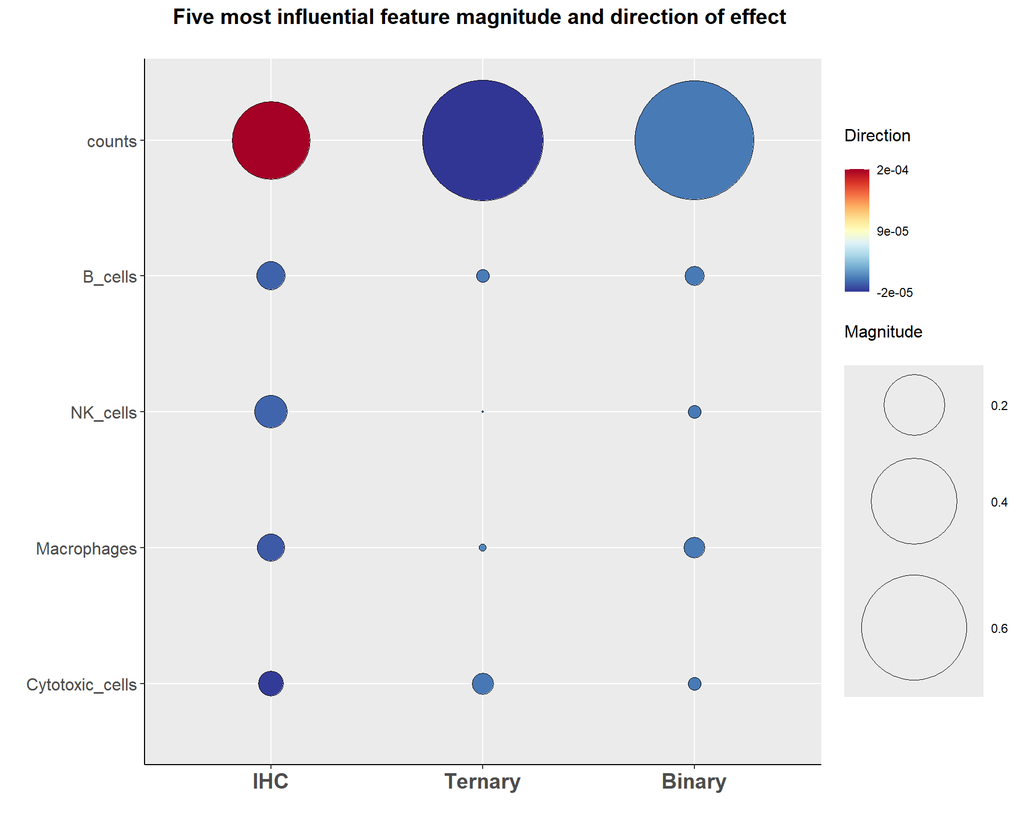

```r
## Balloonplot of the five most important features among thre three
## classifications, showing both the magnitude and direction of the effects

# Names of the features ordered from the most to least important across the
# three classifications
ordinfl_all <- names(sort(rowMeans(overallshap), decreasing = T))

# Table of the overall mean absolute SHAP values (for each classification)
# ordered from the most to least important across the three classifications
bestshap <- overallshap[ordinfl_all, ]
bestshap <- data.frame(cells = rownames(bestshap), bestshap)
# Same table but in long format
bestshaplong <- reshape2::melt(bestshap, id.vars = "cells")
# Selecting only the values corresponding to the five most important features
balloonshap <- subset(bestshaplong, cells == ordinfl_all[1:5])

# Gradient of colors
colpal <- rev(colorRampPalette(RColorBrewer::brewer.pal(11, "RdYlBu"))(50))

# Table of the overall mean raw SHAP values (for each classification) for the
# five most important features from the most to least important across the
# three classifications (as just done with the overall mean absolute SHAP
# values)
bestshap_dir <- overallshap_dir[ordinfl_all, ]
bestshap_dir <- data.frame(cells = rownames(bestshap_dir), bestshap_dir)
bestshaplong_dir <- reshape2::melt(bestshap_dir, id.vars = "cells")
balloonshap_dir <- subset(bestshaplong_dir, cells == ordinfl_all[1:5])

# Defining the values and labels displayed in the legend of the color gradient
breaksp <- c(min(balloonshap_dir$value), mean(range(balloonshap_dir$value)), max(balloonshap_dir$value))
labelsp <- sprintf("%.e", breaksp)

# Final plot
ggplot(balloonshap, aes(x = variable, y = reorder(cells, value))) + geom_point(aes(size = value,
    fill = balloonshap_dir$value), shape = 21) + scale_size(range = range(balloonshap$value) *
    50) + scale_fill_gradientn(colours = colpal, breaks = breaksp, labels = labelsp) +
    labs(x = "", y = "", title = "Five most influential feature magnitude and direction of effect \n",
        size = "Magnitude \n", fill = "Direction \n") + theme_gray() + theme(panel.grid.minor = element_blank(),
    axis.line = element_line(color = "black"), axis.text = element_text(size = 12),
    axis.text.x = element_text(size = 15, face = "bold"), plot.title = element_text(size = 15,
        face = "bold", hjust = 0.5), legend.title = element_text(size = 12))
```

### ML MODELS EXCLUDING IMMUNOLOGICAL FEATURES

It can be interesting to check how the immunological features affect the classification performances. Let’s train again the selected models (SVM linear manually tuned, RF with default tuning and XGBoost manually tuned, without retuning *nrounds* and *eta*), using ESR1 expression as the unique feature.

We first reset properly the training parameters.

```r
# Setting of the control parameters for the trained model
controltrain <- trainControl(method = "repeatedcv", number = 5, repeats = 10, sampling = "up",
    classProbs = T, summaryFunction = multiClassSummary, savePredictions = "final")  # ClassProbs=T for saving prediction probabilites, savePredictions='final' for only saving those corresponding to the best model, summaryFunction=multiClassSummary for all metrics
```

```r
## Traditional IHC classification

# Linear SVM manually tuned
IHC_ESR1_svmLineartuned <- mlmodel(train = datatrain[-c(1:19, 22, 23)], model = "svmLinear",
    tunegrid = expand.grid(C = seq(0.2, 3, 0.2)), res = T)  # Best C = 1.2
# Best hyperparameter results C Mean_Balanced_Accuracy Mean_Balanced_AccuracySD
# AUC AUCSD 1.2 0.66105 0.03155613 0.7887384 0.04604046


## Alternative ternary classification

# Linear SVM manually tuned
Ternary_ESR1_svmLineartuned <- mlmodel(train = datatrain[-c(1:19, 21, 23)], model = "svmLinear",
    tunegrid = expand.grid(C = seq(0.2, 3, 0.2)), res = T)  # Best C = 1.8
# Best hyperparameter results C Mean_Balanced_Accuracy Mean_Balanced_AccuracySD
# AUC AUCSD 1.8 0.9969632 0.005382448 1 0


## Alternative binary classification

# Linear SVM manually tuned
Binary_ESR1_svmLineartuned <- mlmodel(train = datatrain[-c(1:19, 21, 22)], model = "svmLinear",
    tunegrid = expand.grid(C = seq(0.2, 3, 0.2)), res = T)  # Best C = 2.6
# Best hyperparameter results C Balanced_Accuracy Balanced_AccuracySD AUC AUCSD
# 2.6 0.9984101 0.003212053 1 0
```

Now we run RF. Here, the default *mtry* is automatically fixed to 2 since there is only a single feature, but in reality only 1 is used.

```r
## Traditional IHC classification

# Default RF
IHC_ESR1_rf <- mlmodel(train = datatrain[-c(1:19, 22, 23)], model = "rf", res = T)  # Best mtry = 2
# Best hyperparameter results mtry Mean_Balanced_Accuracy
# Mean_Balanced_AccuracySD AUC AUCSD 2 0.6436742 0.03032873 0.6410067
# 0.03414814


## Alternative ternary classification

# Default RF
Ternary_ESR1_rf <- mlmodel(train = datatrain[-c(1:19, 21, 23)], model = "rf", res = T)  # Best mtry = 2
# Best hyperparameter results mtry Mean_Balanced_Accuracy
# Mean_Balanced_AccuracySD AUC AUCSD 2 0.9959512 0.009795813 0.9999899
# 4.984026e-05


## Alternative binary classification

# Default RF
Binary_ESR1_rf <- mlmodel(train = datatrain[-c(1:19, 21, 22)], model = "rf", res = T)  # Best mtry = 2
# Best hyperparameter results mtry Balanced_Accuracy Balanced_AccuracySD AUC
# AUCSD 2 1 0 1 0
```

We finally run XGBoost.

For the traditional IHC classification:

```r
# First step
mlmodel(train = datatrain[c(20, 21)], model = "xgbTree", tunegrid = expand.grid(nrounds = c(50,
    100, 150), eta = c(0.05, 0.2, 0.6), max_depth = c(2:5), gamma = 0, colsample_bytree = 1,
    min_child_weight = 1, subsample = 1))
# Best hyperparameter results nrounds max_depth eta gamma colsample_bytree
# min_child_weight subsample Mean_Balanced_Accuracy Mean_Balanced_AccuracySD
# 100 5 0.2 0 1 1 1 0.6436975 0.03001912

# Second step
mlmodel(train = datatrain[c(20, 21)], model = "xgbTree", tunegrid = expand.grid(nrounds = 100,
    eta = c(0.1, 0.2, 0.3), max_depth = c(4:6), gamma = 0, colsample_bytree = 1,
    min_child_weight = c(1:3), subsample = 1))
# Best hyperparameter results nrounds max_depth eta gamma colsample_bytree
# min_child_weight subsample Mean_Balanced_Accuracy Mean_Balanced_AccuracySD
# 100 6 0.3 0 1 3 1 0.645968 0.02811465

# Third step
mlmodel(train = datatrain[c(20, 21)], model = "xgbTree", tunegrid = expand.grid(nrounds = 100,
    eta = 0.3, max_depth = 6, gamma = 0, colsample_bytree = seq(0.4, 1, 0.2), min_child_weight = c(2:4),
    subsample = c(0.5, seq(0.6, 1, 0.2))))
# Best hyperparameter results nrounds max_depth eta gamma colsample_bytree
# min_child_weight subsample Mean_Balanced_Accuracy Mean_Balanced_AccuracySD
# 100 6 0.3 0 1 4 0.5 0.650541 0.0298948

# Fourth step
IHC_ESR1_xgboosttuned <- mlmodel(train = datatrain[c(20, 21)], model = "xgbTree",
    tunegrid = expand.grid(nrounds = 100, eta = 0.3, max_depth = 6, gamma = c(0,
        0.1, seq(0.2, 1, 0.2)), colsample_bytree = 1, min_child_weight = 4, subsample = 0.5),
    res = T)
# Best hyperparameter results nrounds max_depth eta gamma colsample_bytree
# min_child_weight subsample Mean_Balanced_Accuracy Mean_Balanced_AccuracySD
# 100 6 0.3 0.2 1 4 0.5 0.6496457 0.03024881
```

For the alternative ternary classification:

```r
# First step
mlmodel(train = datatrain[c(20, 22)], model = "xgbTree", tunegrid = expand.grid(nrounds = c(50,
    100, 150), eta = c(0.05, 0.2, 0.6), max_depth = c(2:5), gamma = 0, colsample_bytree = 1,
    min_child_weight = 1, subsample = 1))
# Best hyperparameter results nrounds max_depth eta gamma colsample_bytree
# min_child_weight subsample Mean_Balanced_Accuracy Mean_Balanced_AccuracySD 50
# 2 0.05 0 1 1 1 0.9959512 0.009795813

# Second step
mlmodel(train = datatrain[c(20, 22)], model = "xgbTree", tunegrid = expand.grid(nrounds = 50,
    eta = c(0.001, 0.005, 0.01, 0.05), max_depth = c(1:3), gamma = 0, colsample_bytree = 1,
    min_child_weight = c(1:3), subsample = 1))
# Best hyperparameter results nrounds max_depth eta gamma colsample_bytree
# min_child_weight subsample Mean_Balanced_Accuracy Mean_Balanced_AccuracySD 50
# 1 0.001 0 1 1 1 0.9959512 0.009795813

# Third step
mlmodel(train = datatrain[c(20, 22)], model = "xgbTree", tunegrid = expand.grid(nrounds = 50,
    eta = 0.001, max_depth = 1, gamma = 0, colsample_bytree = seq(0.4, 1, 0.2), min_child_weight = 1,
    subsample = c(0.5, seq(0.6, 1, 0.2))))
# Best hyperparameter results nrounds max_depth eta gamma colsample_bytree
# min_child_weight subsample Mean_Balanced_Accuracy Mean_Balanced_AccuracySD 50
# 1 0.001 0 0.6 1 0.6 0.9965203 0.008740941

# Fourth step
Ternary_ESR1_xgboosttuned <- mlmodel(train = datatrain[c(20, 22)], model = "xgbTree",
    tunegrid = expand.grid(nrounds = 50, eta = 0.001, max_depth = 1, gamma = c(0,
        0.1, seq(0.2, 1, 0.2)), colsample_bytree = 0.6, min_child_weight = 1, subsample = 0.6),
    res = T)
# Best hyperparameter results nrounds max_depth eta gamma colsample_bytree
# min_child_weight subsample Mean_Balanced_Accuracy Mean_Balanced_AccuracySD 50
# 1 0.001 0.1 0.6 1 0.6 0.9966914 0.00872326
```

For the alternative binary classification:

```r
# First step
mlmodel(train = datatrain[c(20, 23)], model = "xgbTree", tunegrid = expand.grid(nrounds = c(50,
    100, 150), eta = c(0.05, 0.2, 0.6), max_depth = c(2:5), gamma = 0, colsample_bytree = 1,
    min_child_weight = 1, subsample = 1))
# Best hyperparameter results nrounds max_depth eta gamma colsample_bytree
# min_child_weight subsample Mean_Balanced_Accuracy Mean_Balanced_AccuracySD 50
# 2 0.05 0 1 1 1 1 0

# Second step
mlmodel(train = datatrain[c(20, 23)], model = "xgbTree", tunegrid = expand.grid(nrounds = 50,
    eta = c(0.001, 0.005, 0.01, 0.05), max_depth = c(1:3), gamma = 0, colsample_bytree = 1,
    min_child_weight = c(1:3), subsample = 1))
# Best hyperparameter results nrounds max_depth eta gamma colsample_bytree
# min_child_weight subsample Mean_Balanced_Accuracy Mean_Balanced_AccuracySD 50
# 1 0.001 0 1 1 1 1 0

# Third step
mlmodel(train = datatrain[c(20, 23)], model = "xgbTree", tunegrid = expand.grid(nrounds = 50,
    eta = 0.001, max_depth = 1, gamma = 0, colsample_bytree = seq(0.4, 1, 0.2), min_child_weight = 1,
    subsample = c(0.5, seq(0.6, 1, 0.2))))
# Best hyperparameter results nrounds max_depth eta gamma colsample_bytree
# min_child_weight subsample Mean_Balanced_Accuracy Mean_Balanced_AccuracySD 50
# 1 0.001 0 0.4 1 0.8 1 0

# Fourth step
Binary_ESR1_xgboosttuned <- mlmodel(train = datatrain[c(20, 23)], model = "xgbTree",
    tunegrid = expand.grid(nrounds = 50, eta = 0.001, max_depth = 1, gamma = c(0,
        0.1, seq(0.2, 1, 0.2)), colsample_bytree = 0.4, min_child_weight = 1, subsample = 0.8),
    res = T)
# Best hyperparameter results nrounds max_depth eta gamma colsample_bytree
# min_child_weight subsample Mean_Balanced_Accuracy Mean_Balanced_AccuracySD 50
# 1 0.001 0 0.4 1 0.8 1 0
```

As we did before, we save those models as a single list.

#modelsESR1 <- list(IHC_svmLineartuned=IHC_svmLineartuned, Ternary_svmLineartuned=Ternary_svmLineartuned, Binary_svmLineartuned=Binary_svmLineartuned, IHC_rf=IHC_rf, Ternary_rf=Ternary_rf, Binary_rf=Binary_rf, IHC_xgboosttuned=IHC_xgboosttuned, Ternary_xgboosttuned=Ternary_xgboosttuned, Binary_xgboosttuned=Binary_xgboosttuned)

#save(modelsESR1, file=“modelsESR1.rda”)

Now we can load this list directly:

```r
# Loading the ML models based on ESR1 only
load(file = "modelsESR1.rda")
```

We apply our custom function of comparison to compare the 9 original models with these 9 based on ESR1 only:

```r
# Comparing the original ML models with the ESR1-only ML models SVM models
compMLmodels(model1 = modelsML[grep("svm", names(modelsML))], model2 = modelsESR1[grep("svm",
    names(modelsML))])
```

```
CLASSIFICATION: IHC

 Best hyperparameters:

$IHC_svmLineartuned
    C
8 1.6

$IHC_ESR1_svmLineartuned
    C
6 1.2


 Mean_Balanced_Accuracy

Call:
summary.resamples(object = modelresults, metric = metriccomp)

Models: IHC_svmLineartuned, IHC_ESR1_svmLineartuned
Number of resamples: 50

Mean_Balanced_Accuracy
                             Min.   1st Qu.    Median      Mean   3rd Qu.
IHC_svmLineartuned      0.5716149 0.6617378 0.7050753 0.6987673 0.7334585
IHC_ESR1_svmLineartuned 0.5937124 0.6408537 0.6603360 0.6610500 0.6786539
                             Max. NA's
IHC_svmLineartuned      0.8343077    0
IHC_ESR1_svmLineartuned 0.7435562    0
```

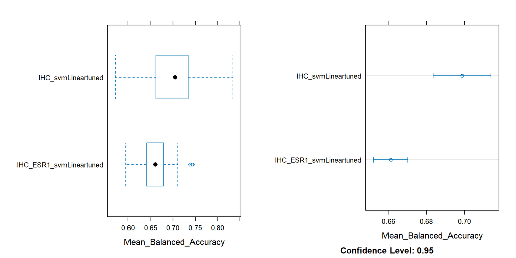

```
 Confidence intervals:
                    model     lower     upper
1 IHC_ESR1_svmLineartuned 0.6520819 0.6700182
2      IHC_svmLineartuned 0.6835037 0.7140309

 Pairwise comparisons:

Call:
summary.diff.resamples(object = diff(modelresults, metric = metriccomp))

p-value adjustment: bonferroni
Upper diagonal: estimates of the difference
Lower diagonal: p-value for H0: difference = 0

Mean_Balanced_Accuracy
                        IHC_svmLineartuned IHC_ESR1_svmLineartuned
IHC_svmLineartuned                         0.03772
IHC_ESR1_svmLineartuned 6.467e-05



CLASSIFICATION: Ternary

 Best hyperparameters:

$Ternary_svmLineartuned
     C
13 2.6

$Ternary_ESR1_svmLineartuned
    C
9 1.8


 Mean_Balanced_Accuracy

Call:
summary.resamples(object = modelresults, metric = metriccomp)

Models: Ternary_svmLineartuned, Ternary_ESR1_svmLineartuned
Number of resamples: 50

Mean_Balanced_Accuracy
                                 Min.   1st Qu.    Median      Mean   3rd Qu.
Ternary_svmLineartuned      0.9360274 0.9567942 0.9805448 0.9736708 0.9832485
Ternary_ESR1_svmLineartuned 0.9813024 0.9918740 1.0000000 0.9969632 1.0000000
                            Max. NA's
Ternary_svmLineartuned         1    0
Ternary_ESR1_svmLineartuned    1    0
```

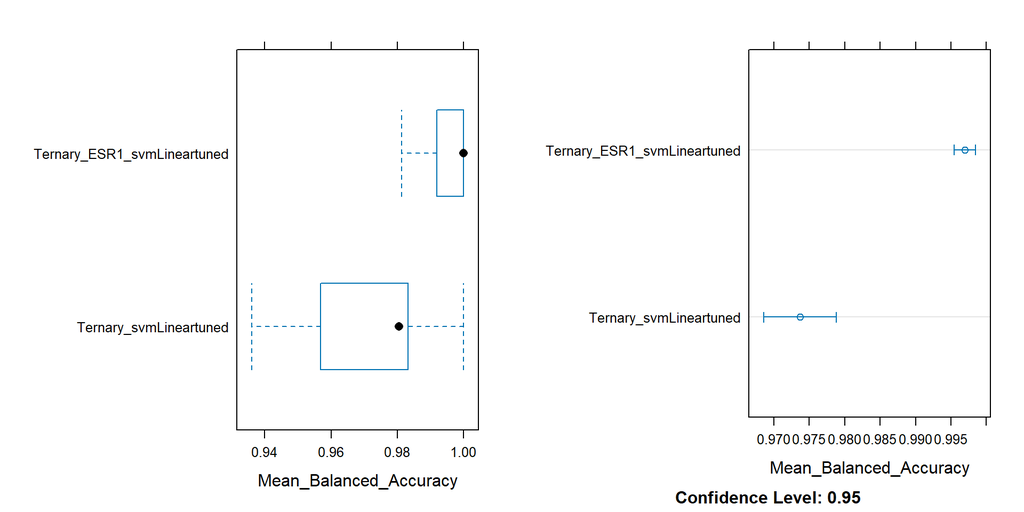

```
 Confidence intervals:
                        model     lower     upper
1      Ternary_svmLineartuned 0.9685340 0.9788075
2 Ternary_ESR1_svmLineartuned 0.9954335 0.9984929

 Pairwise comparisons:

Call:
summary.diff.resamples(object = diff(modelresults, metric = metriccomp))

p-value adjustment: bonferroni
Upper diagonal: estimates of the difference
Lower diagonal: p-value for H0: difference = 0

Mean_Balanced_Accuracy
                            Ternary_svmLineartuned Ternary_ESR1_svmLineartuned
Ternary_svmLineartuned                             -0.02329
Ternary_ESR1_svmLineartuned 2.094e-12



CLASSIFICATION: Binary

 Best hyperparameters:

$Binary_svmLineartuned
    C
8 1.6

$Binary_ESR1_svmLineartuned
     C
13 2.6


 Balanced_Accuracy

Call:
summary.resamples(object = modelresults, metric = metriccomp)

Models: Binary_svmLineartuned, Binary_ESR1_svmLineartuned
Number of resamples: 50

Balanced_Accuracy
                                Min.   1st Qu. Median      Mean 3rd Qu. Max.
Binary_svmLineartuned      0.9087302 0.9615385      1 0.9795060       1    1
Binary_ESR1_svmLineartuned 0.9919355 1.0000000      1 0.9984101       1    1
                           NA's
Binary_svmLineartuned         0
Binary_ESR1_svmLineartuned    0
```

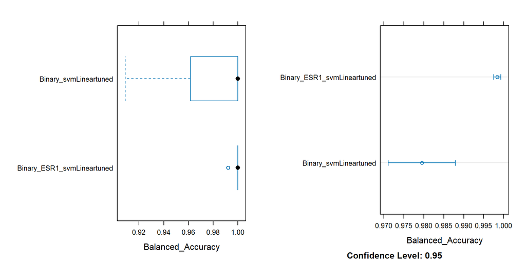

```
 Confidence intervals:
                       model     lower     upper
1      Binary_svmLineartuned 0.9710726 0.9879393
2 Binary_ESR1_svmLineartuned 0.9974973 0.9993230

 Pairwise comparisons:

Call:
summary.diff.resamples(object = diff(modelresults, metric = metriccomp))

p-value adjustment: bonferroni
Upper diagonal: estimates of the difference
Lower diagonal: p-value for H0: difference = 0

Balanced_Accuracy
                           Binary_svmLineartuned Binary_ESR1_svmLineartuned
Binary_svmLineartuned                            -0.0189
Binary_ESR1_svmLineartuned 3.885e-05
```

```r
# RF models
compMLmodels(model1 = modelsML[grep("rf", names(modelsML))], model2 = modelsESR1[grep("rf",
    names(modelsML))])
```

```
CLASSIFICATION: IHC

 Best hyperparameters:

$IHC_rf
  mtry
3    9

$IHC_ESR1_rf
  mtry
1    2


 Mean_Balanced_Accuracy

Call:
summary.resamples(object = modelresults, metric = metriccomp)

Models: IHC_rf, IHC_ESR1_rf
Number of resamples: 50

Mean_Balanced_Accuracy
                 Min.   1st Qu.    Median      Mean   3rd Qu.      Max. NA's
IHC_rf      0.6037350 0.6560208 0.6710149 0.6723694 0.6887215 0.7678314    0
IHC_ESR1_rf 0.5871841 0.6249157 0.6492707 0.6436742 0.6635428 0.7114758    0
```

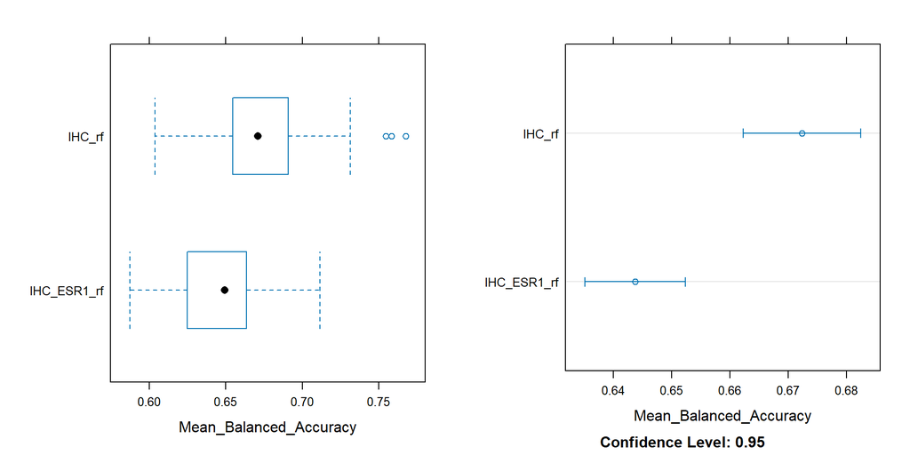

```
 Confidence intervals:
        model     lower     upper
1 IHC_ESR1_rf 0.6350548 0.6522935
2      IHC_rf 0.6622827 0.6824561

 Pairwise comparisons:

Call:
summary.diff.resamples(object = diff(modelresults, metric = metriccomp))

p-value adjustment: bonferroni
Upper diagonal: estimates of the difference
Lower diagonal: p-value for H0: difference = 0

Mean_Balanced_Accuracy
            IHC_rf    IHC_ESR1_rf
IHC_rf                0.0287
IHC_ESR1_rf 6.759e-06



CLASSIFICATION: Ternary

 Best hyperparameters:

$Ternary_rf
  mtry
5   16

$Ternary_ESR1_rf
  mtry
1    2


 Mean_Balanced_Accuracy

Call:
summary.resamples(object = modelresults, metric = metriccomp)

Models: Ternary_rf, Ternary_ESR1_rf
Number of resamples: 50

Mean_Balanced_Accuracy
                     Min.   1st Qu. Median      Mean 3rd Qu. Max. NA's
Ternary_rf      0.9547758 0.9938682      1 0.9959512       1    1    0
Ternary_ESR1_rf 0.9547758 0.9938682      1 0.9959512       1    1    0
```

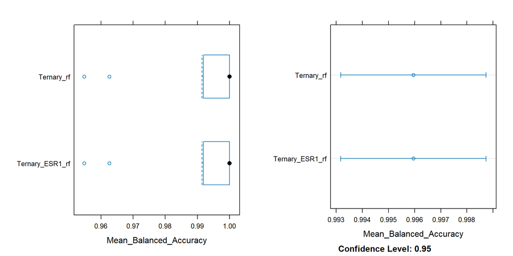

```
 Confidence intervals:
            model     lower     upper
1 Ternary_ESR1_rf 0.9931672 0.9987351
2      Ternary_rf 0.9931672 0.9987351

 Pairwise comparisons:

Call:
summary.diff.resamples(object = diff(modelresults, metric = metriccomp))

p-value adjustment: bonferroni
Upper diagonal: estimates of the difference
Lower diagonal: p-value for H0: difference = 0

Mean_Balanced_Accuracy
                Ternary_rf Ternary_ESR1_rf
Ternary_rf                  0
Ternary_ESR1_rf NA



CLASSIFICATION: Binary

 Best hyperparameters:

$Binary_rf
  mtry
5   16

$Binary_ESR1_rf
  mtry
1    2


 Balanced_Accuracy

Call:
summary.resamples(object = modelresults, metric = metriccomp)

Models: Binary_rf, Binary_ESR1_rf
Number of resamples: 50

Balanced_Accuracy
               Min. 1st Qu. Median Mean 3rd Qu. Max. NA's
Binary_rf         1       1      1    1       1    1    0
Binary_ESR1_rf    1       1      1    1       1    1    0
```

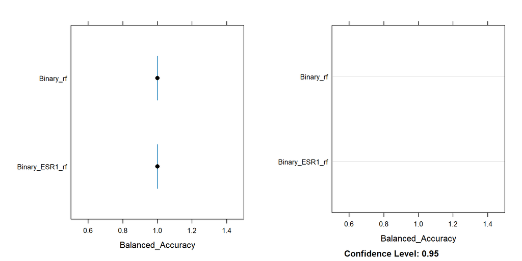

```
 Confidence intervals:
           model lower upper
1 Binary_ESR1_rf    NA    NA
2      Binary_rf    NA    NA

 Pairwise comparisons:

Call:
summary.diff.resamples(object = diff(modelresults, metric = metriccomp))

p-value adjustment: bonferroni
Upper diagonal: estimates of the difference
Lower diagonal: p-value for H0: difference = 0

Balanced_Accuracy
               Binary_rf Binary_ESR1_rf
Binary_rf                 0
Binary_ESR1_rf NA
```

```r
# XGBoost models
compMLmodels(model1 = modelsML[grep("xgboost", names(modelsML))], model2 = modelsESR1[grep("xgboost",
    names(modelsML))])
```

```
CLASSIFICATION: IHC

 Best hyperparameters:

$IHC_xgboosttuned
  nrounds max_depth eta gamma colsample_bytree min_child_weight subsample
7     100         4 0.2     1              0.6                3       0.6

$IHC_ESR1_xgboosttuned
  nrounds max_depth eta gamma colsample_bytree min_child_weight subsample
3     100         6 0.3   0.2                1                4       0.5


 Mean_Balanced_Accuracy

Call:
summary.resamples(object = modelresults, metric = metriccomp)

Models: IHC_xgboosttuned, IHC_ESR1_xgboosttuned
Number of resamples: 50

Mean_Balanced_Accuracy
                           Min.   1st Qu.    Median      Mean   3rd Qu.
IHC_xgboosttuned      0.5914054 0.6578954 0.6718828 0.6765289 0.6899446
IHC_ESR1_xgboosttuned 0.5899295 0.6285939 0.6470105 0.6496457 0.6664995
                           Max. NA's
IHC_xgboosttuned      0.8000213    0
IHC_ESR1_xgboosttuned 0.7114758    0
```

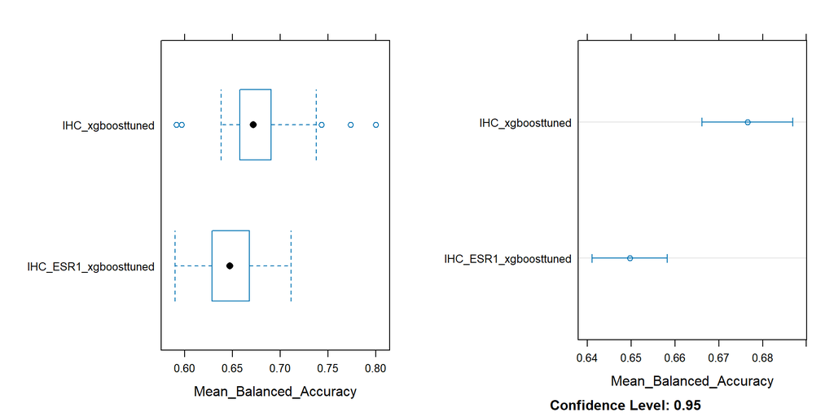

```
 Confidence intervals:
                  model     lower     upper
1 IHC_ESR1_xgboosttuned 0.6410491 0.6582423
2      IHC_xgboosttuned 0.6661765 0.6868814

 Pairwise comparisons:

Call:
summary.diff.resamples(object = diff(modelresults, metric = metriccomp))

p-value adjustment: bonferroni
Upper diagonal: estimates of the difference
Lower diagonal: p-value for H0: difference = 0

Mean_Balanced_Accuracy
                      IHC_xgboosttuned IHC_ESR1_xgboosttuned
IHC_xgboosttuned                       0.02688
IHC_ESR1_xgboosttuned 0.0002595



CLASSIFICATION: Ternary

 Best hyperparameters:

$Ternary_xgboosttuned
  nrounds max_depth   eta gamma colsample_bytree min_child_weight subsample
1      50         1 0.001     0              0.6                1         1

$Ternary_ESR1_xgboosttuned
  nrounds max_depth   eta gamma colsample_bytree min_child_weight subsample
2      50         1 0.001   0.1              0.6                1       0.6


 Mean_Balanced_Accuracy

Call:
summary.resamples(object = modelresults, metric = metriccomp)

Models: Ternary_xgboosttuned, Ternary_ESR1_xgboosttuned
Number of resamples: 50

Mean_Balanced_Accuracy
                               Min.   1st Qu. Median      Mean 3rd Qu. Max.
Ternary_xgboosttuned      0.9547758 0.9938682      1 0.9959512       1    1
Ternary_ESR1_xgboosttuned 0.9547758 1.0000000      1 0.9966914       1    1
                          NA's
Ternary_xgboosttuned         0
Ternary_ESR1_xgboosttuned    0
```

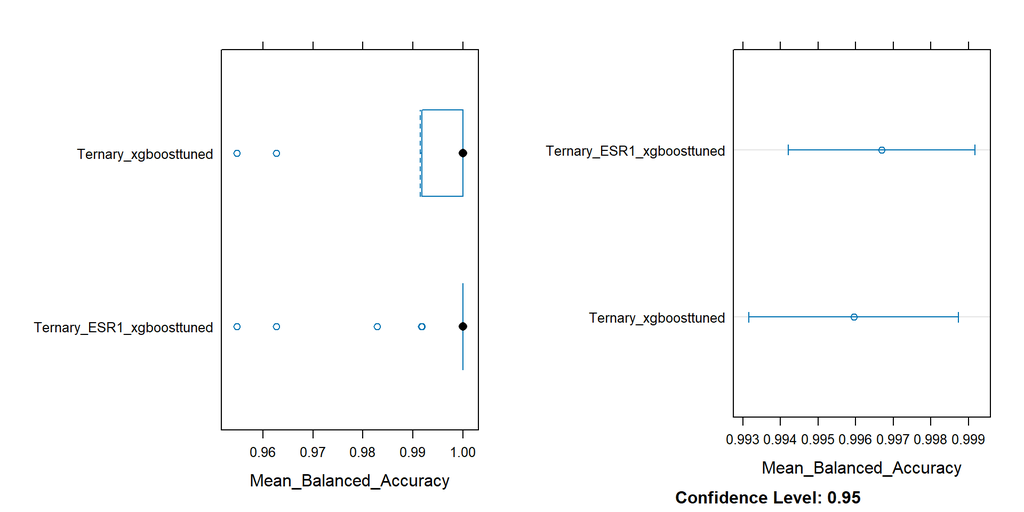

```
 Confidence intervals:
                      model     lower     upper
1      Ternary_xgboosttuned 0.9931672 0.9987351
2 Ternary_ESR1_xgboosttuned 0.9942123 0.9991706

 Pairwise comparisons:

Call:
summary.diff.resamples(object = diff(modelresults, metric = metriccomp))

p-value adjustment: bonferroni
Upper diagonal: estimates of the difference
Lower diagonal: p-value for H0: difference = 0

Mean_Balanced_Accuracy
                          Ternary_xgboosttuned Ternary_ESR1_xgboosttuned
Ternary_xgboosttuned                           -0.0007403
Ternary_ESR1_xgboosttuned 0.3505



CLASSIFICATION: Binary

 Best hyperparameters:

$Binary_xgboosttuned
  nrounds max_depth   eta gamma colsample_bytree min_child_weight subsample
1      50         1 0.001     0              0.6                1       0.6

$Binary_ESR1_xgboosttuned
  nrounds max_depth   eta gamma colsample_bytree min_child_weight subsample
1      50         1 0.001     0              0.4                1       0.8


 Balanced_Accuracy

Call:
summary.resamples(object = modelresults, metric = metriccomp)

Models: Binary_xgboosttuned, Binary_ESR1_xgboosttuned
Number of resamples: 50

Balanced_Accuracy
                         Min. 1st Qu. Median Mean 3rd Qu. Max. NA's
Binary_xgboosttuned         1       1      1    1       1    1    0
Binary_ESR1_xgboosttuned    1       1      1    1       1    1    0
```

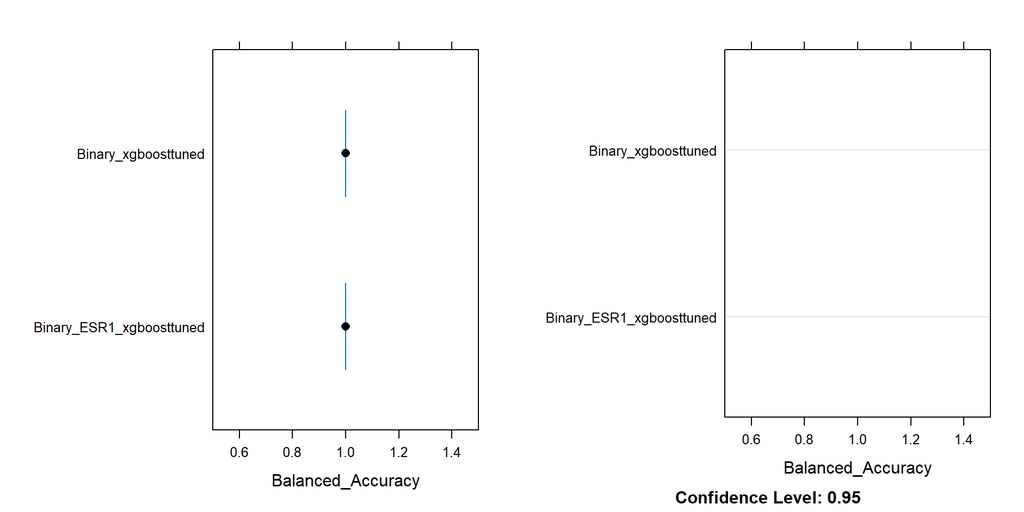

```
 Confidence intervals:
                     model lower upper
1 Binary_ESR1_xgboosttuned    NA    NA
2      Binary_xgboosttuned    NA    NA

 Pairwise comparisons:

Call:
summary.diff.resamples(object = diff(modelresults, metric = metriccomp))

p-value adjustment: bonferroni
Upper diagonal: estimates of the difference
Lower diagonal: p-value for H0: difference = 0

Balanced_Accuracy
                         Binary_xgboosttuned Binary_ESR1_xgboosttuned
Binary_xgboosttuned                           0
Binary_ESR1_xgboosttuned NA
```

- Traditional IHC classification: SVM with immunological features performs significantly better than without (ESR1 only), the increase in balanced accuracy is 3.77%. Same for RF with an increase in balanced accuracy of 2.87%. Same for XGBOOST with an increase in balanced accuracy of 2.69%.
- Alternative ternary classification: SVM with immunological features performs significantly WORSE than without (ESR1 only), the decrease in balanced accuracy is 2.33%. For RF the two models PERFORMS THE EXACT SAME. For XGBOOST the two models perform very slighly differently but DO NOT DIFFER SIGNIFICANTLY.
- Alternative binary classification: SVM with immunological features performs significantly WORSE than without (ESR1 only), the decrease in balanced accuracy is 1.89%. For RF the two models PERFORMS THE SAME. Same for XGBOOST.